# Lab 4 - Multinomial Regression - Questions

Author

Suyog Chandramouli

Published

March 20, 2025

Lab Goal: Predict voting frequency using demographic variables Data source: FiveThirtyEight “Why Many Americans Don’t Vote” survey Method: Multinomial logistic regression

## Data

The data for this assignment comes from an online Ipsos survey that was conducted for the FiveThirtyEight article [“Why Many Americans Don’t Vote”](https://projects.fivethirtyeight.com/non-voters-poll-2020-election/). You can read more about the survey design and respondents in the README of the [GitHub repo](https://github.com/fivethirtyeight/data/tree/master/non-voters) for the data.

Respondents were asked a variety of questions about their political beliefs, thoughts on multiple issues, and voting behavior. We will focus on using the demographic variables and someone’s party identification to understand whether a person is a probable voter.

The variables we’ll focus on were (definitions from the codebook in data set GitHub repo):

- `ppage`: Age of respondent
- `educ`: Highest educational attainment category.
- `race`: Race of respondent, census categories. Note: all categories except Hispanic were non-Hispanic.
- `gender`: Gender of respondent
- `income_cat`: Household income category of respondent
- `Q30`: Response to the question “Generally speaking, do you think of yourself as a…”
  - 1: Republican
  - 2: Democrat
  - 3: Independent
  - 4: Another party, please specify
  - 5: No preference
  - -1: No response
- `voter_category`: past voting behavior:
  - **always**: respondent voted in all or all-but-one of the elections they were eligible in
  - **sporadic**: respondent voted in at least two, but fewer than all-but-one of the elections they were eligible in
  - **rarely/never**: respondent voted in 0 or 1 of the elections they were eligible in

You can read in the data directly from the GitHub repo:

```r
library(nnet)
library(car)
library(tidyverse)
library(emmeans)
library(ggeffects)
library(knitr)
library(patchwork)
library(broom)
library(parameters)
library(easystats)
```

```r
voter_data <- read_csv("https://raw.githubusercontent.com/fivethirtyeight/data/master/non-voters/nonvoters_data.csv")
```

# Lab

- The variable `Q30` contains the respondent’s political party identification. Make a new variable that simplifies `Q30` into four categories: “Democrat”, “Republican”, “Independent”, “Other” (“Other” also includes respondents who did not answer the question).

```r
voter_data <- voter_data %>%
  mutate(pol_ident_new = case_when(
    Q30==1 ~ "Rep",
    Q30==2 ~ "Dem",
    Q30==3 ~ "Indep",
    TRUE ~ "Other"
  ))
```

- The variable `voter_category` identifies the respondent’s past voter behavior. Relevel the variable to make rarely/never the baseline level, followed by sporadic, then always

```r
#Enter your code
voter_data$voter_category <- factor(voter_data$voter_category, levels = c('rarely/never', 'sporadic','always'))
```

- Center the age variable to make the intercept more interepretable. That is, so that it reflects the log-odds for an average-aged person rather than a 0-year old person

```r
# enter code
voter_data <- voter_data %>%
  mutate(age_centered = ppage - mean(ppage, na.rm = TRUE))
```

- In the [FiveThirtyEight article](https://projects.fivethirtyeight.com/non-voters-poll-2020-election/), the authors include visualizations of the relationship between the voter category and demographic variables such as race, age, education, etc. Select two demographic variables. For each variable, try to replicate the visualizations and interpret the plot to describe its relationship with voter category. Have fun with it: https://www.mikelee.co/posts/2020-02-08-recreate-fivethirtyeight-chicklet-stacked-bar-chart-in-ggplot2.

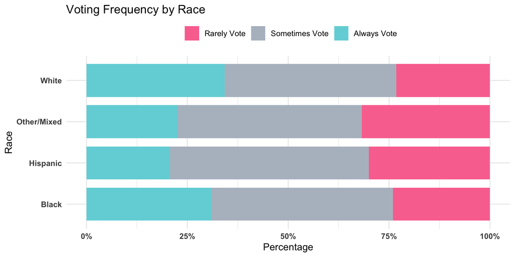

```r
# library
library(ggplot2)
library(viridis)
library(cowplot)
library(ggtext)

# Enter code

plot_race <- ggplot(voter_data, aes(x = race, fill = voter_category)) +
  geom_bar(position = "fill", width = 0.8) +
  scale_y_continuous(labels = scales::percent_format()) +
  scale_fill_manual(values = c("rarely/never" = "#FA759F", "sporadic" = "#B5BEC9", "always" = "#72D4DB"), labels = c("Rarely Vote", "Sometimes Vote", "Always Vote")) +
  theme_minimal() +
  labs(
    title = "Voting Frequency by Race",
    x = "Race",
    y = "Percentage",
    fill = ""
  ) +
  theme(
    legend.position = "top",
    axis.text.x = element_text(face = "bold"),
    axis.text.y = element_text(face = "bold")
  ) + coord_flip()
plot_race
```

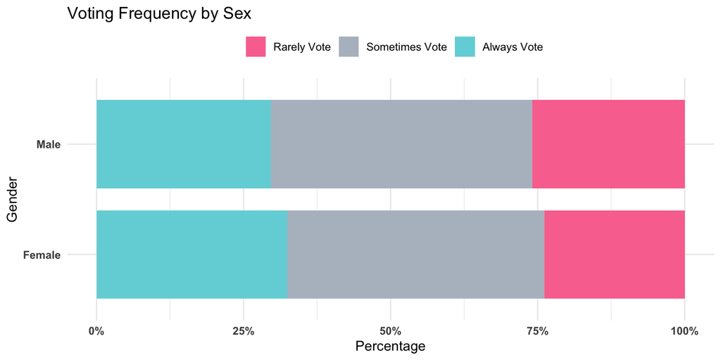

```r
# Enter code
plot_sex <- ggplot(voter_data, aes(x = gender, fill = voter_category)) +
  geom_bar(position = "fill", width = 0.8) +
  scale_y_continuous(labels = scales::percent_format()) +
  scale_fill_manual(values = c("rarely/never" = "#FA759F", "sporadic" = "#B5BEC9", "always" = "#72D4DB"), labels = c("Rarely Vote", "Sometimes Vote", "Always Vote")) +
  theme_minimal() +
  labs(
    title = "Voting Frequency by Sex",
    x = "Gender",
    y = "Percentage",
    fill = ""
  ) +
  theme(
    legend.position = "top",
    axis.text.x = element_text(face = "bold"),
    axis.text.y = element_text(face = "bold")
  ) +  coord_flip()
plot_sex
```

The plots can be combined into a single plot using the patchwork package.

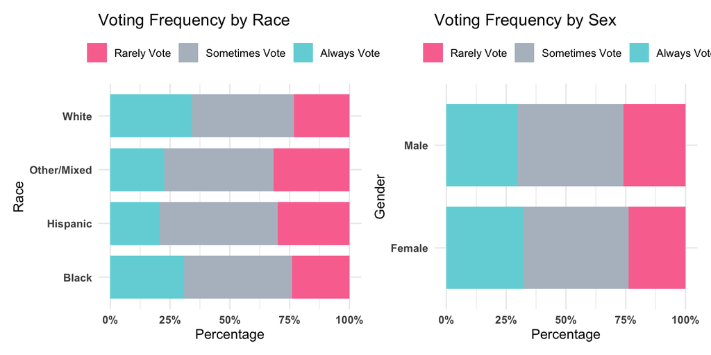

```r
library(patchwork)
# Enter code
combined_plot <- plot_race | plot_sex
combined_plot
```

- Fit a model using mean-centered age, race, gender, income, and education to predict voter category. Show the code used to fit the model, but do **not** display the model output.

```r
library(nnet)

    #Enter code
model <- multinom(voter_category ~ age_centered + race + gender + income_cat + educ, data = voter_data)
summary(model)
```

```
Call:
multinom(formula = voter_category ~ age_centered + race + gender +
    income_cat + educ, data = voter_data)

Coefficients:
         (Intercept) age_centered raceHispanic raceOther/Mixed   raceWhite
sporadic    1.571743   0.04756726 -0.006572206      -0.3728753 -0.12744623
always      1.278666   0.06059743 -0.417261709      -0.6828026  0.03919505
          genderMale income_cat$40-75k income_cat$75-125k
sporadic -0.09611637       -0.12720892      -0.0008412738
always   -0.21057744       -0.06689241       0.1466532354
         income_catLess than $40k educHigh school or less educSome college
sporadic               -0.6625535              -0.9221798       -0.3570304
always                 -0.7563303              -1.3530154       -0.4119784

Std. Errors:
         (Intercept) age_centered raceHispanic raceOther/Mixed raceWhite
sporadic   0.1313271  0.002287702    0.1256837       0.1567315 0.1017369
always     0.1418943  0.002524055    0.1467286       0.1824467 0.1112169
         genderMale income_cat$40-75k income_cat$75-125k
sporadic 0.07068749         0.1102118          0.1059291
always   0.07785548         0.1195723          0.1132269
         income_catLess than $40k educHigh school or less educSome college
sporadic                0.1121235              0.09566347       0.09377139
always                  0.1249826              0.10670619       0.10048308

Residual Deviance: 11386.63
AIC: 11430.63
```

- *Should party identification be added to the model?*
- #Hint: Use an anova test to make the determination

```r
#Enter code
model_no_party <- multinom(voter_category ~ age_centered + race + gender + income_cat + educ, data = voter_data)
# Fit the model with party identification
model_with_party <- multinom(voter_category ~ age_centered + race + gender + income_cat + educ + pol_ident_new, data = voter_data)
# Perform an ANOVA test to compare the two models
anova_result <- anova(model_no_party, model_with_party, test = "Chisq")

# Display the ANOVA result (to check p-value)
tibble(anova_result)
```

```
# A tibble: 2 × 7
  Model              `Resid. df` `Resid. Dev` Test  `   Df` `LR stat.` `Pr(Chi)`
  <chr>                    <dbl>        <dbl> <chr>   <dbl>      <dbl>     <dbl>
1 age_centered + ra…       11650       11387. ""         NA        NA         NA
2 age_centered + ra…       11644       11233. "1 v…       6       154.         0
```

```
> #Enter answer based on your code: Party identification significantly contributes to the model's fit
```

**Use the model you select for the remainder of the assignment**.